# Copy of Apriori Recommendation System_2

```python
import pandas as pd
import numpy as np
import matplotlib.pyplot as plt
import seaborn as sns
```

```python
# ✅ Mount Google Drive
from google.colab import drive
drive.mount('/content/drive')
```

```python
data = pd.read_csv("/content/drive/My Drive/SMU MSDS/Decision Analysis/Project/Coffee Shop Sales_2.csv")

#from google.colab import files
#uploaded = files.upload()
```

```python
#data = pd.read_csv("apriori_data.csv")

data.sample(20)
```

|  | Unnamed: 0 | transaction_id | transaction_date | transaction_time | sales_outlet_id | staff_id | customer_id | instore_yn | order | line_item_id | ... | tax_exempt_yn | promo_yn | new_product_yn | customer_first-name | customer_email | customer_since | loyalty_card_number | gender | birth_year | generation |
| --- | --- | --- | --- | --- | --- | --- | --- | --- | --- | --- | --- | --- | --- | --- | --- | --- | --- | --- | --- | --- | --- |
| 16903 | 16903 | 110 | 4/11/2019 | 7:26:34 | 3 | 20 | 0 | N | 1 | 1 | ... | Y | N | N | Unknown | Unknown | Unknown | Unknown | Unknown | Unknown | Unknown |
| 45070 | 45070 | 236 | 4/27/2019 | 14:54:04 | 3 | 16 | 136 | N | 1 | 1 | ... | Y | N | N | Neil Bonner | Preston@lorem.us | 1/11/2018 | 026-221-2273 | M | 1973.0 | Gen X |
| 35229 | 35229 | 330 | 4/21/2019 | 15:46:03 | 3 | 17 | 767 | Y | 1 | 1 | ... | Y | N | N | Tyrone Hewitt | Vera@inceptos.gov | 7/10/2018 | 612-963-9575 | N | 1984.0 | Older Millennials |
| 17636 | 17636 | 277 | 4/11/2019 | 7:57:57 | 5 | 26 | 5169 | Y | 1 | 1 | ... | Y | N | N | Gail | Lani@viverra.net | 8/1/2018 | 181-989-4834 | F | 1985.0 | Older Millennials |
| 13678 | 13678 | 353 | 4/9/2019 | 12:44:14 | 3 | 10 | 347 | Y | 1 | 3 | ... | N | N | N | Abra Dotson | Penelope@taciti.org | 4/9/2017 | 659-894-5363 | F | 1956.0 | Baby Boomers |
| 37696 | 37696 | 324 | 4/22/2019 | 8:40:41 | 8 | 42 | 8247 | N | 1 | 1 | ... | Y | N | N | Natalie | Irene@volutpat.gov | 2/23/2018 | 322-761-0794 | F | 1954.0 | Baby Boomers |
| 33633 | 33633 | 410 | 4/20/2019 | 16:46:40 | 3 | 8 | 229 | N | 1 | 5 | ... | N | N | N | Craig Mathis | Amery@porta.org | 9/25/2018 | 212-840-4513 | M | 1989.0 | Older Millennials |
| 4829 | 4829 | 2049 | 4/3/2019 | 15:39:35 | 8 | 42 | 8220 | Y | 1 | 1 | ... | Y | N | N | Hermione | Baker@Donec.edu | 9/29/2017 | 568-085-8311 | F | 1959.0 | Baby Boomers |
| 10463 | 10463 | 202 | 4/7/2019 | 10:32:10 | 5 | 14 | 5098 | N | 1 | 1 | ... | Y | N | N | Odessa | Deanna@lacinia.org | 10/21/2018 | 309-117-4600 | F | 1990.0 | Younger Millennials |
| 28298 | 28298 | 697 | 4/17/2019 | 6:09:10 | 5 | 12 | 0 | Y | 1 | 1 | ... | Y | N | N | Unknown | Unknown | Unknown | Unknown | Unknown | Unknown | Unknown |
| 14928 | 14928 | 477 | 4/9/2019 | 13:37:11 | 8 | 43 | 0 | Y | 1 | 1 | ... | Y | N | N | Unknown | Unknown | Unknown | Unknown | Unknown | Unknown | Unknown |
| 36912 | 36912 | 3194 | 4/22/2019 | 8:29:39 | 3 | 14 | 0 | Y | 1 | 1 | ... | Y | N | N | Unknown | Unknown | Unknown | Unknown | Unknown | Unknown | Unknown |
| 40776 | 40776 | 1044 | 4/24/2019 | 9:16:51 | 5 | 28 | 0 | Y | 1 | 1 | ... | Y | N | N | Unknown | Unknown | Unknown | Unknown | Unknown | Unknown | Unknown |
| 27638 | 27638 | 588 | 4/17/2019 | 10:32:47 | 3 | 16 | 0 | N | 1 | 2 | ... | Y | N | N | Unknown | Unknown | Unknown | Unknown | Unknown | Unknown | Unknown |
| 41359 | 41359 | 1258 | 4/24/2019 | 7:36:24 | 8 | 6 | 0 | N | 1 | 1 | ... | Y | N | N | Unknown | Unknown | Unknown | Unknown | Unknown | Unknown | Unknown |
| 27942 | 27942 | 1482 | 4/17/2019 | 11:16:12 | 3 | 12 | 423 | N | 1 | 5 | ... | N | N | N | Kylie Hooper | Shellie@Proin.com | 9/13/2017 | 809-903-2967 | F | 1965.0 | Gen X |
| 22486 | 22486 | 19 | 4/14/2019 | 10:08:38 | 5 | 12 | 5816 | N | 1 | 1 | ... | Y | N | N | Brett | Jared@primis.edu | 10/10/2017 | 855-942-9581 | N | 1987.0 | Older Millennials |
| 2585 | 2585 | 1747 | 4/2/2019 | 10:07:28 | 5 | 12 | 5628 | N | 1 | 1 | ... | Y | N | N | Francesca | Owen@tellus.us | 12/19/2017 | 843-577-6771 | F | 1971.0 | Gen X |
| 18200 | 18200 | 239 | 4/11/2019 | 8:44:39 | 8 | 42 | 8270 | Y | 1 | 1 | ... | Y | N | N | Sawyer | Hayes@ornare.org | 6/9/2017 | 661-093-4045 | M | 1995.0 | Gen Z |
| 3271 | 3271 | 2721 | 4/2/2019 | 14:41:12 | 8 | 15 | 8413 | N | 1 | 1 | ... | Y | N | N | Sheila | Kyla@odio.org | 11/17/2018 | 668-920-6949 | N | 1994.0 | Younger Millennials |

20 rows × 32 columns

```python
data.info()
```

```
<class 'pandas.core.frame.DataFrame'>
RangeIndex: 49893 entries, 0 to 49892
Data columns (total 32 columns):
 #   Column                   Non-Null Count  Dtype
---  ------                   --------------  -----
 0   Unnamed: 0               49893 non-null  int64
 1   transaction_id           49893 non-null  int64
 2   transaction_date         49893 non-null  object
 3   transaction_time         49893 non-null  object
 4   sales_outlet_id          49893 non-null  int64
 5   staff_id                 49893 non-null  int64
 6   customer_id              49893 non-null  int64
 7   instore_yn               49893 non-null  object
 8   order                    49893 non-null  int64
 9   line_item_id             49893 non-null  int64
```

[output cut: 24 more lines]

```python
data.describe().T
```

|  | count | mean | std | min | 25% | 50% | 75% | max |
| --- | --- | --- | --- | --- | --- | --- | --- | --- |
| Unnamed: 0 | 49893.0 | 24946.000000 | 14403.012827 | 0.00 | 12473.0 | 24946.00 | 37419.00 | 49892.0 |
| transaction_id | 49893.0 | 869.068587 | 857.867182 | 1.00 | 223.0 | 481.00 | 1401.00 | 4203.0 |
| sales_outlet_id | 49893.0 | 5.351793 | 2.074783 | 3.00 | 3.0 | 5.00 | 8.00 | 8.0 |
| staff_id | 49893.0 | 25.359209 | 12.466336 | 6.00 | 15.0 | 26.00 | 41.00 | 45.0 |
| customer_id | 49893.0 | 2281.167639 | 3240.115997 | 0.00 | 0.0 | 0.00 | 5412.00 | 8501.0 |
| order | 49893.0 | 1.173431 | 1.025455 | 1.00 | 1.0 | 1.00 | 1.00 | 9.0 |
| line_item_id | 49893.0 | 1.631872 | 1.412892 | 1.00 | 1.0 | 1.00 | 1.00 | 12.0 |
| product_id | 49893.0 | 47.879422 | 17.928267 | 1.00 | 33.0 | 47.00 | 60.00 | 87.0 |
| quantity | 49893.0 | 1.438218 | 0.543041 | 1.00 | 1.0 | 1.00 | 2.00 | 8.0 |
| line_item_amount | 49893.0 | 4.682680 | 4.436706 | 0.00 | 3.0 | 3.75 | 6.00 | 360.0 |
| unit_price | 49893.0 | 3.384653 | 2.682571 | 0.80 | 2.5 | 3.00 | 3.75 | 45.0 |
| current_wholesale_price | 49893.0 | 1.356459 | 2.201821 | 0.04 | 0.6 | 0.75 | 1.95 | 36.0 |
| current_retail_price | 49893.0 | 3.388293 | 2.672441 | 0.80 | 2.5 | 3.00 | 3.75 | 45.0 |

```python
data.head()
```

|  | Unnamed: 0 | transaction_id | transaction_date | transaction_time | sales_outlet_id | staff_id | customer_id | instore_yn | order | line_item_id | ... | tax_exempt_yn | promo_yn | new_product_yn | customer_first-name | customer_email | customer_since | loyalty_card_number | gender | birth_year | generation |
| --- | --- | --- | --- | --- | --- | --- | --- | --- | --- | --- | --- | --- | --- | --- | --- | --- | --- | --- | --- | --- | --- |
| 0 | 0 | 7 | 4/1/2019 | 12:04:43 | 3 | 12 | 558 | N | 1 | 1 | ... | Y | N | N | Melissa Johnson | Luke@eget.net | 6/19/2018 | 816-924-9433 | F | 1983.0 | Older Millennials |
| 1 | 1 | 11 | 4/1/2019 | 15:54:39 | 3 | 17 | 781 | N | 1 | 1 | ... | Y | N | N | Luke Patel | Herrod@Maecenas.us | 11/2/2018 | 653-218-9979 | N | 1991.0 | Younger Millennials |
| 2 | 2 | 19 | 4/1/2019 | 14:34:59 | 3 | 17 | 788 | Y | 1 | 1 | ... | Y | N | N | Hilel Ballard | Rajah@risus.org | 12/30/2018 | 263-826-9026 | N | 1995.0 | Gen Z |
| 3 | 3 | 32 | 4/1/2019 | 16:06:04 | 3 | 12 | 683 | N | 1 | 1 | ... | Y | N | N | Zephr Zimmerman | Dacey@in.net | 3/4/2019 | 741-320-7166 | F | 1999.0 | Gen Z |
| 4 | 4 | 33 | 4/1/2019 | 19:18:37 | 3 | 17 | 99 | Y | 1 | 1 | ... | Y | N | N | Orlando Shields | Ivory@scelerisque.us | 10/1/2017 | 747-164-4596 | M | 1967.0 | Gen X |

5 rows × 32 columns

```python
# Remove the 'Unnamed: 0' column
if 'Unnamed: 0' in data.columns:
    data = data.drop('Unnamed: 0', axis=1)

# Remove rows with 'Unknown' values in any column
data = data[~data.isin(['Unknown']).any(axis=1)]

# Display the first few rows to confirm the column is removed
display(data.head(10))
```

|  | transaction_id | transaction_date | transaction_time | sales_outlet_id | staff_id | customer_id | instore_yn | order | line_item_id | product_id | ... | tax_exempt_yn | promo_yn | new_product_yn | customer_first-name | customer_email | customer_since | loyalty_card_number | gender | birth_year | generation |
| --- | --- | --- | --- | --- | --- | --- | --- | --- | --- | --- | --- | --- | --- | --- | --- | --- | --- | --- | --- | --- | --- |
| 0 | 7 | 4/1/2019 | 12:04:43 | 3 | 12 | 558 | N | 1 | 1 | 52 | ... | Y | N | N | Melissa Johnson | Luke@eget.net | 6/19/2018 | 816-924-9433 | F | 1983.0 | Older Millennials |
| 1 | 11 | 4/1/2019 | 15:54:39 | 3 | 17 | 781 | N | 1 | 1 | 27 | ... | Y | N | N | Luke Patel | Herrod@Maecenas.us | 11/2/2018 | 653-218-9979 | N | 1991.0 | Younger Millennials |
| 2 | 19 | 4/1/2019 | 14:34:59 | 3 | 17 | 788 | Y | 1 | 1 | 46 | ... | Y | N | N | Hilel Ballard | Rajah@risus.org | 12/30/2018 | 263-826-9026 | N | 1995.0 | Gen Z |
| 3 | 32 | 4/1/2019 | 16:06:04 | 3 | 12 | 683 | N | 1 | 1 | 23 | ... | Y | N | N | Zephr Zimmerman | Dacey@in.net | 3/4/2019 | 741-320-7166 | F | 1999.0 | Gen Z |
| 4 | 33 | 4/1/2019 | 19:18:37 | 3 | 17 | 99 | Y | 1 | 1 | 34 | ... | Y | N | N | Orlando Shields | Ivory@scelerisque.us | 10/1/2017 | 747-164-4596 | M | 1967.0 | Gen X |
| 5 | 39 | 4/1/2019 | 18:54:46 | 3 | 17 | 664 | Y | 1 | 1 | 32 | ... | Y | N | N | Portia Acevedo | Karly@risus.org | 1/24/2019 | 410-846-1380 | F | 1996.0 | Gen Z |
| 6 | 50 | 4/1/2019 | 13:03:49 | 3 | 12 | 316 | N | 1 | 1 | 49 | ... | Y | N | N | Camille Glass | Hedley@adipiscing.gov | 2/4/2017 | 448-528-3198 | F | 1952.0 | Baby Boomers |
| 7 | 53 | 4/1/2019 | 11:21:14 | 3 | 12 | 38 | N | 1 | 1 | 60 | ... | Y | N | N | Xanthus Puckett | Kylynn@aliquam.gov | 4/16/2017 | 436-942-8673 | M | 1956.0 | Baby Boomers |
| 8 | 59 | 4/1/2019 | 19:30:55 | 3 | 12 | 370 | Y | 1 | 1 | 51 | ... | Y | N | N | Kameko Knox | Bianca@eget.org | 5/26/2017 | 769-640-0042 | F | 1959.0 | Baby Boomers |
| 9 | 62 | 4/1/2019 | 12:01:00 | 3 | 12 | 180 | Y | 1 | 1 | 49 | ... | Y | N | N | Calvin Potter | George@at.net | 5/13/2018 | 574-419-3111 | M | 1980.0 | Older Millennials |

10 rows × 31 columns

```python
data['product'].unique()
```

```
array(['Traditional Blend Chai Rg', 'Brazilian Lg',
       'Serenity Green Tea Rg', 'Our Old Time Diner Blend Rg',
       'Jamaican Coffee River Sm', 'Ethiopia Rg', 'English Breakfast Lg',
       'Sustainably Grown Organic Rg', 'Earl Grey Lg',
       'Jamaican Coffee River Rg', 'Serenity Green Tea Lg',
       'Brazilian Sm', 'English Breakfast Rg',
       'Traditional Blend Chai Lg', 'Cappuccino', 'Espresso shot',
       'Cappuccino Lg', 'Latte', 'Earl Grey Rg', 'Dark chocolate Lg',
       'Columbian Medium Roast Sm', 'Oatmeal Scone',
       'Morning Sunrise Chai Lg', 'Morning Sunrise Chai Rg',
       'Peppermint Lg', 'Jumbo Savory Scone', 'Lemon Grass Lg',
       'Sustainably Grown Organic Lg', 'Dark chocolate Rg',
       'Lemon Grass Rg', 'Ethiopia Sm', 'Latte Rg',
       'Our Old Time Diner Blend Sm', 'Chocolate Chip Biscotti',
       'Columbian Medium Roast Rg', 'Ethiopia Lg', 'Brazilian Rg',
       'Columbian Medium Roast Lg', 'Spicy Eye Opener Chai Rg',
       'Ginger Biscotti', 'Our Old Time Diner Blend Lg',
       'Chocolate Croissant', 'Jamaican Coffee River Lg',
       'Hazelnut Biscotti', 'Spicy Eye Opener Chai Lg', 'Cranberry Scone',
       'Peppermint Rg', 'Scottish Cream Scone ', 'Croissant',
       'Almond Croissant', 'Ginger Scone', 'Ouro Brasileiro shot',
       'Chocolate syrup', 'Organic Decaf Blend', 'Peppermint',
       'Carmel syrup', 'Hazelnut syrup', 'Sugar Free Vanilla syrup',
       'Our Old Time Diner Blend', 'English Breakfast',
       'Jamacian Coffee River', 'Spicy Eye Opener Chai', 'Dark chocolate',
       'Guatemalan Sustainably Grown', 'Primo Espresso Roast',
       'Chili Mayan', 'Traditional Blend Chai', 'Espresso Roast',
       'Ethiopia', 'Columbian Medium Roast', 'I Need My Bean! Latte cup',
       'Civet Cat', 'Morning Sunrise Chai', 'Brazilian - Organic',
       'Serenity Green Tea', 'Lemon Grass', 'Sustainably Grown Organic',
       'Earl Grey', 'I Need My Bean! T-shirt',
       'I Need My Bean! Diner mug'], dtype=object)
```

```python
# Create a new column where products are classified and use that columns for recommendation system
#Create DataFrame
df = pd.DataFrame({'product': data['product']})

# Define a function to categorize products
def categorize(product):
    if product in [
        'Traditional Blend Chai Rg', 'Serenity Green Tea Rg', 'Ethiopia Rg', 'English Breakfast Lg',
        'Sustainably Grown Organic Rg', 'Earl Grey Lg', 'Traditional Blend Chai Lg', 'Morning Sunrise Chai Rg',
        'Morning Sunrise Chai Rg', 'Peppermint Lg', 'Lemon Grass Lg', 'Sustainably Grown Organic Lg',
        'Ethiopia Sm', 'Ethiopia Lg', 'Spicy Eye Opener Chai Rg', 'Spicy Eye Opener Chai Lg',
        'Peppermint Rg', 'Guatemalan Sustainably Grown', 'Chili Mayan', 'Ethiopia', 'Morning Sunrise Chai'
    ]:
        return 'Tea'
    elif product in [
        'Brazilian Lg', 'Our Old Time Diner Blend Rg', 'Jamaican Coffee River Sm', 'Brazilian Sm',
        'Cappuccino', 'Espresso shot', 'Cappuccino Lg', 'Latte', 'Columbian Medium Roast Sm',
        'Latte Rg', 'Our Old Time Diner Blend Sm', 'Columbian Medium Roast Rg', 'Brazilian Rg',
        'Columbian Medium Roast Lg', 'Jamaican Coffee River Lg', 'Primo Espresso Roast', 'Espresso Roast',
        'Brazilian - Organic', 'Jamacian Coffee River'
    ]:
        return 'Coffee & Espresso'
    elif product in ['Dark chocolate Lg', 'Dark chocolate Rg']:
        return 'Chocolate & Confectionery'
    elif product in [
        'Oatmeal Scone', 'Jumbo Savory Scone', 'Chocolate Chip Biscotti', 'Ginger Biscotti',
        'Chocolate Croissant', 'Hazelnut Biscotti', 'Cranberry Scone', 'Scottish Cream Scone',
        'Croissant', 'Almond Croissant', 'Ginger Scone'
    ]:
        return 'Baked Goods & Snacks'
    elif product in [
        'Chocolate syrup', 'Carmel syrup', 'Hazelnut syrup', 'Sugar Free Vanilla syrup'
    ]:
        return 'Syrups & Flavored Add-ons'
    elif product == 'Civet Cat':
        return 'Other Beverages'
    elif product in ['I Need My Bean! T-shirt', 'I Need My Bean! Diner mug']:
        return 'Merchandise'
    else:
        return 'Other'

# Apply the function to create a new column
data['prod_cat'] = data['product'].apply(categorize)

# View the resulting DataFrame
data['prod_cat'].unique()
```

```
array(['Tea', 'Coffee & Espresso', 'Other', 'Chocolate & Confectionery',
       'Baked Goods & Snacks', 'Syrups & Flavored Add-ons',
       'Other Beverages', 'Merchandise'], dtype=object)
```

Step-by-Step Roadmap for Building a Recommendation System

1. Segment Existing Customers Use clustering (e.g. K-Means in PCA space) on behavioral features:
- Frequency of purchases (customer_id, order)
- In-store vs online (instore_yn)
- Promotion and tax-exempt behavior (promo_yn, tax_exempt_yn)
- Demographics: gender, birth_year, generation Cluster centroids can serve as prototype profiles for new visitors.
2. Infer Customer Archetype If we collect basic input at check-in (e.g. age group or gender), you can:
- Assign them to the closest segment using nearest-neighbor matching in PCA-reduced feature space.
- Use generation tags as priors (e.g. Baby Boomers show higher tax-exempt behavior).
3. Recommend Based on Cluster Preferences Aggregate top-selling items for each segment and recommend:
- Frequently purchased products by similar customers
- Cross-promoted items that tend to co-occur in the same order

Example logic: top_items = transactions.groupby(['generation', 'product_id'])['order'].sum().sort_values() recommendations = top_items.loc['Gen X'].head(5) # if user is Gen X

4. Embed Robustness Checks Use techniques like:
- Label shuffling on generation to test if segment-specific preferences are statistically robust.
- Permutation importance of demographic features in influencing product choices.
5. Visualization for Interpretability Diagnostic plots:
- Heatmaps of item popularity by generation
- Confusion matrices if you build a classifier to infer customer profile

## 1. Segment Existing Customers

```python
##Preprocess & Engineer Features##
#Before clustering, let’s clean and shape the data:
#- Convert Unknown to NaN and drop rows with insufficient demographic data.
#- Parse birth_year to derive age; bin into generational groups if needed.
#- Encode categorical variables like gender, instore_yn, tax_exempt_yn, and promo_yn.

from sklearn.preprocessing import LabelEncoder

# Convert 'birth_year' to numeric, coercing errors to NaN
data['birth_year'] = pd.to_numeric(data['birth_year'], errors='coerce')

# Drop rows where 'birth_year' is NaN after coercion
data.dropna(subset=['birth_year'], inplace=True)

# Calculate age
data["age"] = 2019 - data["birth_year"]

# Encode categorical variables
le = LabelEncoder()
data["gender"] = le.fit_transform(data["gender"].astype(str))
data["instore_yn"] = le.fit_transform(data["instore_yn"].astype(str))
data["tax_exempt_yn"] = le.fit_transform(data["tax_exempt_yn"].astype(str))
data["promo_yn"] = le.fit_transform(data["promo_yn"].astype(str))

# Display info to check data types and non-null counts
data.info()
```

```
<class 'pandas.core.frame.DataFrame'>
Index: 24852 entries, 0 to 49892
Data columns (total 33 columns):
 #   Column                   Non-Null Count  Dtype
---  ------                   --------------  -----
 0   transaction_id           24852 non-null  int64
 1   transaction_date         24852 non-null  object
 2   transaction_time         24852 non-null  object
 3   sales_outlet_id          24852 non-null  int64
 4   staff_id                 24852 non-null  int64
 5   customer_id              24852 non-null  int64
 6   instore_yn               24852 non-null  int64
 7   order                    24852 non-null  int64
 8   line_item_id             24852 non-null  int64
 9   product_id               24852 non-null  int64
```

[output cut: 25 more lines]

```python
##Select Customer Behavior Features##
#Let's use these for clustering:
#- Purchase activity: number of line_item_id per customer
#- instore_yn, promo_yn, tax_exempt_yn rates
#- Demographics: age, gender, generation
#We'll aggregate per customer_id to build a customer-level feature matrix

features = data.groupby("customer_id").agg({
    "line_item_id": "count",
    "instore_yn": lambda x: (x == "Y").mean(),
    "promo_yn": lambda x: (x == "Y").mean(),
    "tax_exempt_yn": lambda x: (x == "Y").mean(),
    "age": "mean",
    "gender": "mean",
    "generation": "first",
    "birth_year": "first",
    "staff_id": "first",
    "customer_since": "first",
    "sales_outlet_id": "first",
}).dropna()
```

## 2. Infer Customer Archetype

```python
##Apply PCA for Dimensionality Reduction##
#Reduce feature space for better cluster separation

from sklearn.decomposition import PCA
from sklearn.preprocessing import StandardScaler, OneHotEncoder
from sklearn.compose import ColumnTransformer
from sklearn.pipeline import Pipeline

# Identify numerical and categorical columns for scaling and encoding
# Exclude 'customer_since' as it's a date string and not suitable for direct scaling/PCA
# Use column names as they appear in the 'features' DataFrame after aggregation
numerical_features = ['line_item_id', 'instore_yn', 'promo_yn', 'tax_exempt_yn', 'age', 'gender', 'birth_year', 'staff_id', 'sales_outlet_id']
categorical_features = ['generation']

# Create a column transformer to apply different transformations to different columns
# Scale numerical features and one-hot encode categorical features
preprocessor = ColumnTransformer(
    transformers=[
        ('num', StandardScaler(), numerical_features),
        ('cat', OneHotEncoder(handle_unknown='ignore'), categorical_features) # handle_unknown='ignore' to handle potential new categories in test data
    ],
    remainder='drop' # Drop columns not specified in transformers (like customer_since)
)

# Create a pipeline that first preprocesses the data and then applies PCA
pipeline = Pipeline(steps=[('preprocessor', preprocessor),
                           ('pca', PCA(n_components=2))])

# Apply the pipeline to the features DataFrame
X_pca = pipeline.fit_transform(features)

# The output X_pca is a numpy array, so we don't display it directly like a DataFrame
print("PCA transformed data shape:", X_pca.shape)
```

```
PCA transformed data shape: (2245, 2)
```

```python
from sklearn.cluster import KMeans

kmeans = KMeans(n_clusters=3, random_state=42)
```

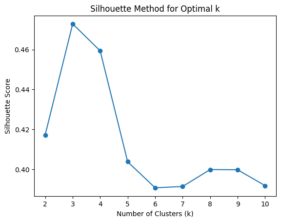

```
Best number of clusters according to silhouette score: 3
```

```python
#Lets check the best cluster to use with our dataset from 10 clusters

from sklearn.metrics import silhouette_score

silhouette_scores = []

for k in range(2, 11):
    kmeans = KMeans(n_clusters=k, random_state=42)
    labels = kmeans.fit_predict(X_pca)
    score = silhouette_score(X_pca, labels)
    silhouette_scores.append(score)

plt.plot(range(2, 11), silhouette_scores, marker='o')
plt.xlabel('Number of Clusters (k)')
plt.ylabel('Silhouette Score')
plt.title('Silhouette Method for Optimal k')
plt.show()

# Find the best k
best_k = range(2, 11)[np.argmax(silhouette_scores)]
print(f"Best number of clusters according to silhouette score: {best_k}")
```

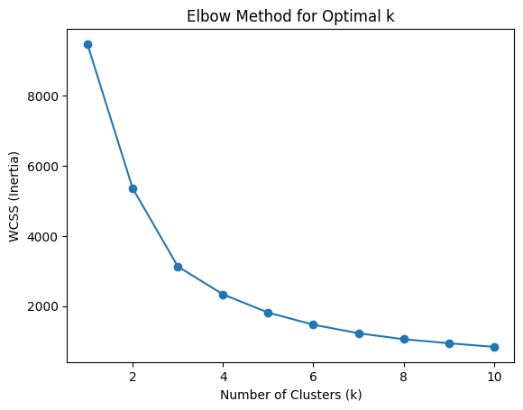

```
Best number of clusters according to elbow score: 3
```

```python
wcss = []
k_range = range(1, 11)

for k in k_range:
    kmeans = KMeans(n_clusters=k, random_state=42)
    kmeans.fit(X_pca)
    wcss.append(kmeans.inertia_)

plt.plot(k_range, wcss, marker='o')
plt.xlabel('Number of Clusters (k)')
plt.ylabel('WCSS (Inertia)')
plt.title('Elbow Method for Optimal k')
plt.show()
# Find the best k
best_wcss = range(2, 11)[np.argmax(wcss)]
print(f"Best number of clusters according to elbow score: {best_k}")
```

```python
##Cluster with K-Means##
#Choose an optimal number of clusters is 3 (using the elbow and silhouette methods)

from sklearn.cluster import KMeans

kmeans = KMeans(n_clusters=3, random_state=42)
features["cluster"] = kmeans.fit_predict(X_pca)
features.sample(10)
```

| customer_id | line_item_id | instore_yn | promo_yn | tax_exempt_yn | age | gender | generation | birth_year | staff_id | customer_since | sales_outlet_id | cluster |
| --- | --- | --- | --- | --- | --- | --- | --- | --- | --- | --- | --- | --- |
| 5172 | 4 | 0.0 | 0.0 | 0.0 | 63.0 | 0.0 | Baby Boomers | 1956.0 | 28 | 4/19/2017 | 5 | 0 |
| 5173 | 5 | 0.0 | 0.0 | 0.0 | 63.0 | 1.0 | Baby Boomers | 1956.0 | 30 | 4/12/2017 | 5 | 0 |
| 8479 | 13 | 0.0 | 0.0 | 0.0 | 29.0 | 0.0 | Younger Millennials | 1990.0 | 42 | 12/29/2017 | 8 | 1 |
| 5171 | 14 | 0.0 | 0.0 | 0.0 | 57.0 | 0.0 | Baby Boomers | 1962.0 | 30 | 7/16/2017 | 5 | 0 |
| 8435 | 15 | 0.0 | 0.0 | 0.0 | 27.0 | 0.0 | Younger Millennials | 1992.0 | 15 | 2/4/2019 | 8 | 2 |
| 5204 | 11 | 0.0 | 0.0 | 0.0 | 54.0 | 0.0 | Gen X | 1965.0 | 12 | 9/2/2017 | 5 | 0 |
| 8029 | 13 | 0.0 | 0.0 | 0.0 | 38.0 | 1.0 | Older Millennials | 1981.0 | 42 | 2/7/2018 | 8 | 1 |
| 5784 | 1 | 0.0 | 0.0 | 0.0 | 33.0 | 0.0 | Older Millennials | 1986.0 | 28 | 8/13/2018 | 5 | 2 |
| 8077 | 13 | 0.0 | 0.0 | 0.0 | 45.0 | 0.0 | Gen X | 1974.0 | 15 | 3/6/2017 | 8 | 0 |
| 5918 | 7 | 0.0 | 0.0 | 0.0 | 35.0 | 0.0 | Older Millennials | 1984.0 | 30 | 7/5/2018 | 5 | 2 |

## 3. Recommend Based on Cluster Preferences

```python
##Map New Customer to Closest Segment##
#For each new walk-in customer (especially cold-start cases), we’ll match them to a cluster using available features like age, gender, or store behavior

new_customer = pd.DataFrame({
    "line_item_id": [0],                   # No purchase history yet
    "instore_yn": [1],                     # Visited in-store (Y encoded as 1)
    "promo_yn": [0],                       # No promo applied
    "tax_exempt_yn": [0],                  # Not tax-exempt
    "age": [32],                           # Derived from birth_year
    "gender": [1],
    "generation": ["Gen Z"],               # Derived from birth_year
    "birth_year": [1980.0], # Ensure birth_year is float to match features dataframe dtype
    "staff_id": [1],
    "sales_outlet_id": [1],
    "customer_since": ["2019-01-01"]      # Placeholder - this column will be dropped by the pipeline
})
# Assume new_customer above is DataFrame with matching columns of a new walk-in customer

# Use the fitted pipeline to transform the new customer data
X_new_pca = pipeline.transform(new_customer)

# Predict the cluster label using the fitted kmeans model
new_customer["predicted_cluster"] = kmeans.predict(X_new_pca)

# Display the new customer DataFrame with the predicted cluster
display(new_customer)
```

|  | line_item_id | instore_yn | promo_yn | tax_exempt_yn | age | gender | generation | birth_year | staff_id | sales_outlet_id | customer_since | predicted_cluster |
| --- | --- | --- | --- | --- | --- | --- | --- | --- | --- | --- | --- | --- |
| 0 | 0 | 1 | 0 | 0 | 32 | 1 | Gen Z | 1980.0 | 1 | 1 | 2019-01-01 | 2 |

```python
# The new customer's predicted cluster was already calculated in the previous cell (TtOi2ZfXwfIc)
# and stored in the 'predicted_cluster' column of the new_customer DataFrame.
# We can simply extract it here for use in subsequent steps.

new_customer_cluster = new_customer['predicted_cluster'].iloc[0]

print(f"New customer's predicted cluster: {new_customer_cluster}")
```

```
New customer's predicted cluster: 2
```

```python
##Generate Segment-Based Recommendations##
#We will mine past purchases from each cluster to build personalized recommendations

# Filter existing customers in the same cluster
matched_customers = features[features["cluster"] == new_customer_cluster].index
cluster_transactions = data[data["customer_id"].isin(matched_customers)]

# Get top products for this segment
top_products = cluster_transactions["prod_cat"].value_counts().head(5)
print(top_products)
```

```
prod_cat
Tea                          3307
Coffee & Espresso            2896
Other                        1749
Baked Goods & Snacks         1506
Chocolate & Confectionery     370
Name: count, dtype: int64
```

```python
##Filter & Diversify Recommendations##
#These strategies refine your system’s signal-to-noise ratio. For implementation:
#- Exclude Purchased/Returned Items

# Contextual recommendation filter
contextual_recs = data[
    (data["sales_outlet_id"] == 5) &
    (data["promo_yn"] == "Y")
]
```

```python
# Step 1: Prepare data for Apriori
# Group by transaction_id and get a list of products for each transaction
transactions = data.groupby('transaction_id')['prod_cat'].apply(list).reset_index()

# Display the first few transactions
display(transactions.head())
```

|  | transaction_id | prod_cat |
| --- | --- | --- |
| 0 | 1 | [Chocolate & Confectionery, Tea, Baked Goods &... |
| 1 | 2 | [Other, Other, Tea, Coffee & Espresso, Coffee ... |
| 2 | 3 | [Tea, Coffee & Espresso, Tea, Other, Other, Co... |
| 3 | 4 | [Other, Tea, Coffee & Espresso, Tea, Other, Ot... |
| 4 | 5 | [Tea, Baked Goods & Snacks, Other, Baked Goods... |

```python
%pip install mlxtend
```

```python
# Step 2: Apply Apriori algorithm
from mlxtend.preprocessing import TransactionEncoder
from mlxtend.frequent_patterns import apriori

# Convert the list of transactions into a one-hot encoded DataFrame
te = TransactionEncoder()
te_ary = te.fit(transactions['prod_cat']).transform(transactions['prod_cat'])
df = pd.DataFrame(te_ary, columns=te.columns_)

# Apply the apriori algorithm to find frequent itemsets
# You can adjust the min_support threshold as needed
freq_items = apriori(df, min_support=0.01, use_colnames=True)

# Display the frequent itemsets
display(freq_items.head())
```

|  | support | itemsets |
| --- | --- | --- |
| 0 | 0.509671 | (Baked Goods & Snacks) |
| 1 | 0.225668 | (Chocolate & Confectionery) |
| 2 | 0.770648 | (Coffee & Espresso) |
| 3 | 0.014123 | (Merchandise) |
| 4 | 0.600553 | (Other) |

```python
# Step 3: Generate association rules
from mlxtend.frequent_patterns import association_rules

# Generate association rules with a minimum confidence threshold
# You can adjust the min_confidence threshold as needed
rules = association_rules(freq_items, metric="confidence", min_threshold=0.5)

# Display the association rules
display(rules.head())
```

|  | antecedents | consequents | antecedent support | consequent support | support | confidence | lift | representativity | leverage | conviction | zhangs_metric | jaccard | certainty | kulczynski |
| --- | --- | --- | --- | --- | --- | --- | --- | --- | --- | --- | --- | --- | --- | --- |
| 0 | (Chocolate & Confectionery) | (Baked Goods & Snacks) | 0.225668 | 0.509671 | 0.153516 | 0.680272 | 1.334727 | 1.0 | 0.038499 | 1.533581 | 0.323870 | 0.263852 | 0.347931 | 0.490738 |
| 1 | (Coffee & Espresso) | (Baked Goods & Snacks) | 0.770648 | 0.509671 | 0.448879 | 0.582470 | 1.142834 | 1.0 | 0.056102 | 1.174356 | 0.544938 | 0.539882 | 0.148469 | 0.731597 |
| 2 | (Baked Goods & Snacks) | (Coffee & Espresso) | 0.509671 | 0.770648 | 0.448879 | 0.880723 | 1.142834 | 1.0 | 0.056102 | 1.922851 | 0.254896 | 0.539882 | 0.479939 | 0.731597 |
| 3 | (Merchandise) | (Baked Goods & Snacks) | 0.014123 | 0.509671 | 0.013202 | 0.934783 | 1.834089 | 1.0 | 0.006004 | 7.518371 | 0.461285 | 0.025857 | 0.866992 | 0.480343 |
| 4 | (Baked Goods & Snacks) | (Other) | 0.509671 | 0.600553 | 0.373043 | 0.731928 | 1.218757 | 1.0 | 0.066958 | 1.490073 | 0.366064 | 0.506039 | 0.328892 | 0.676547 |

```python
# Step 4: Implement recommendation logic
def recommend_items(items_purchased, rules, top_n=5):
    """
    Recommends items based on the association rules and items purchased by a new customer.

    Args:
        items_purchased (list): A list of items the customer is purchasing.
        rules (pd.DataFrame): DataFrame containing the association rules.
        top_n (int): The maximum number of recommendations to return.

    Returns:
        list: A list of recommended items.
    """
    recommendations = []
    for item in items_purchased:
        # Find rules where the purchased item is in the antecedent
        relevant_rules = rules[rules['antecedents'].apply(lambda x: item in x)]

        # If no relevant rules are found for the item, continue to the next item
        if relevant_rules.empty:
            continue

        # Sort rules by confidence and lift
        relevant_rules = relevant_rules.sort_values(by=['confidence', 'lift'], ascending=False)

        # Add consequents to recommendations, avoiding items already purchased
        for index, row in relevant_rules.iterrows():
            consequent = list(row['consequents'])[0]
            if consequent not in items_purchased and consequent not in recommendations:
                recommendations.append(consequent)
            if len(recommendations) >= top_n:
                break
        if len(recommendations) >= top_n:
            break

    return recommendations[:top_n]
```

```python
# Step 5: Test the recommendation system 1

# Example: Simulate a new customer purchasing these items
items_purchased_example = ['Tea', 'Baked Goods & Snacks']

# Get recommendations for the example customer
recommendations_example = recommend_items(items_purchased_example, rules)

# Display the recommendations
print(f"Items purchased: {items_purchased_example}")
print(f"Recommended items: {recommendations_example}")
```

```
Items purchased: ['Tea', 'Baked Goods & Snacks']
Recommended items: ['Coffee & Espresso', 'Other', 'Syrups & Flavored Add-ons']
```

```python
# Step 5: Test the recommendation system 2

# Example: Simulate a new customer purchasing these items
items_purchased_example = ['Merchandise', 'Chocolate & Confectionery']

# Get recommendations for the example customer
recommendations_example = recommend_items(items_purchased_example, rules)

# Display the recommendations
print(f"Items purchased: {items_purchased_example}")
print(f"Recommended items: {recommendations_example}")
```

```
Items purchased: ['Merchandise', 'Chocolate & Confectionery']
Recommended items: ['Tea', 'Coffee & Espresso', 'Baked Goods & Snacks', 'Other', 'Syrups & Flavored Add-ons']
```

```python
# Step 5: Test the recommendation system 3

# Example: Simulate a new customer purchasing these items
items_purchased_example = ['Syrups & Flavored Add-ons', 'Other']

# Get recommendations for the example customer
recommendations_example = recommend_items(items_purchased_example, rules)

# Display the recommendations
print(f"Items purchased: {items_purchased_example}")
print(f"Recommended items: {recommendations_example}")
```

```
Items purchased: ['Syrups & Flavored Add-ons', 'Other']
Recommended items: ['Coffee & Espresso', 'Tea', 'Baked Goods & Snacks']
```

```python
# Step 5: Test the recommendation system 2

# Example: Simulate a new customer purchasing these items
items_purchased_example = ['Merchandise', 'Chocolate & Confectionery']

# Get recommendations for the example customer
recommendations_example = recommend_items(items_purchased_example, rules)

# Display the recommendations
print(f"Items purchased: {items_purchased_example}")
print(f"Recommended items: {recommendations_example}")
```

```
Items purchased: ['Merchandise', 'Chocolate & Confectionery']
Recommended items: ['Tea', 'Coffee & Espresso', 'Baked Goods & Snacks', 'Other', 'Syrups & Flavored Add-ons']
```

```python
items_purchased_example = ["Coffee & Espresso", "Syrups & Flavored Add-ons"]
print(f"Recommended items: {recommendations_example}")
```

[output not shown]

```python
# Split the data into training and testing sets (80% train, 20% test)
from sklearn.model_selection import train_test_split

# Assuming 'transactions' DataFrame is available from previous steps
train_transactions, test_transactions = train_test_split(transactions, test_size=0.2, random_state=42)

print(f"Training set size: {len(train_transactions)}")
print(f"Testing set size: {len(test_transactions)}")

# Retrain the Apriori model on the training data using the best hyperparameters
from mlxtend.preprocessing import TransactionEncoder
from mlxtend.frequent_patterns import apriori, association_rules

# Convert the training transactions into a one-hot encoded DataFrame
te = TransactionEncoder()
te_ary_train = te.fit(train_transactions['prod_cat']).transform(train_transactions['prod_cat']) # Using 'prod_cat' as in previous successful Apriori steps
df_train = pd.DataFrame(te_ary_train, columns=te.columns_)

# Apply the apriori algorithm to find frequent itemsets in the training data with best min_support
freq_items_train_best = apriori(df_train, min_support=best_min_support, use_colnames=True)

# Generate association rules from the frequent itemsets in the training data with best min_confidence
rules_train_best = association_rules(freq_items_train_best, metric="confidence", min_threshold=best_min_confidence)

# Display the generated rules from the training set
display(rules_train_best.head())
```

[output not shown]

```
Training set size: 2605
Testing set size: 652
```

|  | antecedents | consequents | antecedent support | consequent support | support | confidence | lift | representativity | leverage | conviction | zhangs_metric | jaccard | certainty | kulczynski |
| --- | --- | --- | --- | --- | --- | --- | --- | --- | --- | --- | --- | --- | --- | --- |
| 0 | (Chocolate & Confectionery) | (Baked Goods & Snacks) | 0.218810 | 0.509789 | 0.145873 | 0.666667 | 1.307731 | 1.0 | 0.034326 | 1.470633 | 0.301229 | 0.250329 | 0.320021 | 0.476406 |
| 1 | (Baked Goods & Snacks) | (Coffee & Espresso) | 0.509789 | 0.766603 | 0.448369 | 0.879518 | 1.147293 | 1.0 | 0.057563 | 1.937198 | 0.261894 | 0.541493 | 0.483790 | 0.732198 |
| 2 | (Merchandise) | (Baked Goods & Snacks) | 0.012284 | 0.509789 | 0.011516 | 0.937500 | 1.838997 | 1.0 | 0.005254 | 7.843378 | 0.461899 | 0.022556 | 0.872504 | 0.480045 |
| 3 | (Baked Goods & Snacks) | (Other) | 0.509789 | 0.594242 | 0.371209 | 0.728163 | 1.225364 | 1.0 | 0.068271 | 1.492651 | 0.375177 | 0.506548 | 0.330051 | 0.676420 |
| 4 | (Syrups & Flavored Add-ons) | (Baked Goods & Snacks) | 0.157006 | 0.509789 | 0.130902 | 0.833741 | 1.635463 | 1.0 | 0.050862 | 2.948476 | 0.460919 | 0.244269 | 0.660842 | 0.545259 |

```python
# Give recommendations on the test data
# Iterate through a few test transactions and generate recommendations

print("Generating recommendations for test data transactions:")

# Get the first few transactions from the test set
sample_test_transactions = test_transactions.head(5)

for index, row in sample_test_transactions.iterrows():
    transaction_id = row['transaction_id']
    items_in_transaction = row['prod_cat'] # Using 'prod_cat' as used in Apriori steps

    # Get recommendations for the items in the transaction
    recommendations = recommend_items(items_in_transaction, rules_train_best)

    print(f"\nTransaction ID: {transaction_id}")
    print(f"Items in transaction: {items_in_transaction}")
    print(f"Recommended items: {recommendations}")
```

```
Generating recommendations for test data transactions:

Transaction ID: 2830
Items in transaction: ['Other', 'Tea']
Recommended items: ['Coffee & Espresso', 'Baked Goods & Snacks']

Transaction ID: 135
Items in transaction: ['Coffee & Espresso', 'Tea', 'Coffee & Espresso', 'Tea', 'Baked Goods & Snacks', 'Coffee & Espresso', 'Other', 'Other', 'Coffee & Espresso', 'Baked Goods & Snacks', 'Chocolate & Confectionery', 'Coffee & Espresso', 'Syrups & Flavored Add-ons', 'Other', 'Other', 'Tea', 'Other', …
Recommended items: []

Transaction ID: 2300
Items in transaction: ['Other', 'Chocolate & Confectionery', 'Coffee & Espresso', 'Coffee & Espresso']
Recommended items: ['Tea', 'Baked Goods & Snacks']

Transaction ID: 1611
Items in transaction: ['Coffee & Espresso', 'Tea', 'Tea', 'Tea', 'Tea']
Recommended items: ['Baked Goods & Snacks', 'Other']

Transaction ID: 991
Items in transaction: ['Tea', 'Tea', 'Tea', 'Other', 'Coffee & Espresso', 'Syrups & Flavored Add-ons', 'Tea']
Recommended items: ['Baked Goods & Snacks']
```

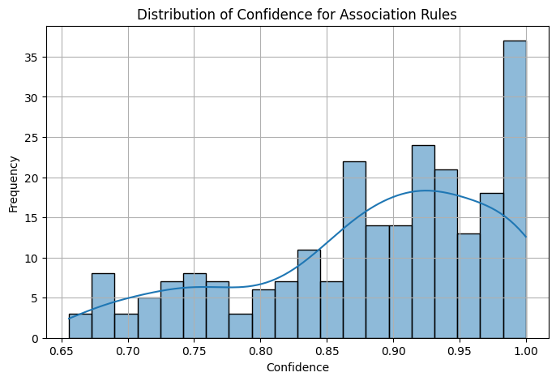

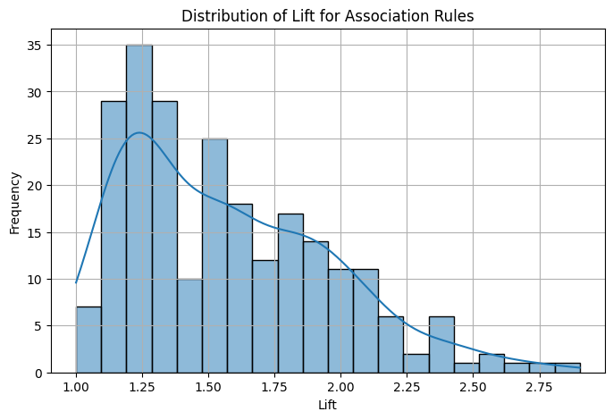

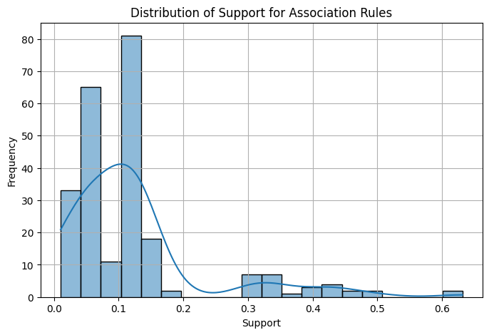

```python
# Plot the distribution of confidence
plt.figure(figsize=(8, 5))
sns.histplot(rules_train_best['confidence'], bins=20, kde=True)
plt.title('Distribution of Confidence for Association Rules')
plt.xlabel('Confidence')
plt.ylabel('Frequency')
plt.grid(True)
plt.show()

# Plot the distribution of lift
plt.figure(figsize=(8, 5))
sns.histplot(rules_train_best['lift'], bins=20, kde=True)
plt.title('Distribution of Lift for Association Rules')
plt.xlabel('Lift')
plt.ylabel('Frequency')
plt.grid(True)
plt.show()

#  plot support distribution
plt.figure(figsize=(8, 5))
sns.histplot(rules_train_best['support'], bins=20, kde=True)
plt.title('Distribution of Support for Association Rules')
plt.xlabel('Support')
plt.ylabel('Frequency')
plt.grid(True)
plt.show()

#  plot consequents distribution - This code caused an error because histplot cannot directly plot frozensets
# plt.figure(figsize=(8, 5))
# sns.histplot(rules_train_best['consequents'], bins=20, kde=True)
# plt.title('Distribution of Consequents for Association Rules')
# plt.xlabel('Consequents')
# plt.ylabel('Frequency')
# plt.grid(True)
# plt.show()
```

Confidence Plot: The histogram for Confidence shows the distribution of confidence values across all the generated association rules.

A bar on the right side of the plot (closer to 1.0) indicates that many rules have high confidence, meaning the consequent is very likely to occur when the antecedent is present in a transaction. This suggests strong relationships between the items in these rules. A bar on the left side (closer to the min_confidence threshold, which was 0.65 for the rules used in the plot) indicates rules that just met the minimum confidence requirement. The shape of the distribution tells us about the overall strength of the rules. A distribution skewed towards higher confidence values means we have found many reliable association rules. Lift Plot: The histogram for Lift shows the distribution of lift values.

A lift value greater than 1 indicates that the antecedent and consequent are more likely to occur together than expected by chance. Higher lift values suggest a stronger positive correlation between the items and that the rule is more "interesting" or potentially useful for recommendations. A lift value of 1 suggests the items are independent. A lift value less than 1 suggests the items are negatively correlated (less likely to occur together than expected). The plot shows that most of the rules have a lift greater than 1, which is good, as it indicates that the relationships found are not just due to items being popular individually but are truly associated. Higher bars at higher lift values mean we have found many rules with strong positive associations.

Support Plot : The histogram show how frequently the itemsets involved in the rules appear in the dataset. Rules with higher support values involve more frequent itemsets. While high support is necessary to find rules (due to the min_support threshold in Apriori), lift and confidence are often more informative about the strength and interestingness of the association itself, especially for recommendation purposes. In summary, these plots visually represent the characteristics of the generated association rules in terms of their reliability (confidence) and interestingness (lift), helping us understand the quality of the rules for making recommendations.

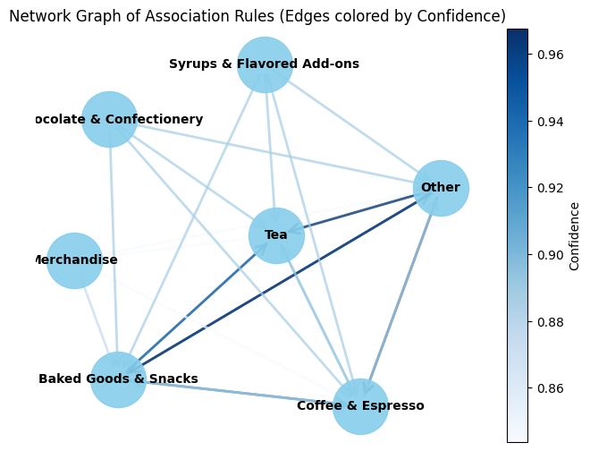

```python
import networkx as nx
import matplotlib.cm as cm # Import cm for ScalarMappable

# Create a directed graph
G = nx.DiGraph()

# Add nodes for each unique item in the rules
all_items = set()
for rule in rules_train_best.itertuples():
    all_items.update(rule.antecedents)
    all_items.update(rule.consequents)

for item in all_items:
    G.add_node(item)

# Add edges for each rule
for rule in rules_train_best.itertuples():
    antecedent = list(rule.antecedents)
    consequent = list(rule.consequents)
    confidence = rule.confidence # Use confidence as edge weight/attribute

    # Add edges from each item in the antecedent to each item in the consequent
    for ant_item in antecedent:
        for con_item in consequent:
            G.add_edge(ant_item, con_item, confidence=confidence)

# Draw the graph
fig, ax = plt.subplots(figsize=(8, 6)) # Create figure and axes explicitly
pos = nx.spring_layout(G, k=0.5, iterations=50) # Use spring layout for better visualization

# Draw nodes
nx.draw_networkx_nodes(G, pos, ax=ax, node_size=2000, node_color='skyblue', alpha=0.9)

# Draw edges with weights indicating confidence
edges = G.edges(data=True)
edge_colors = [edge[2]['confidence'] for edge in edges]
# Create a ScalarMappable to map edge colors to the colormap
sm = cm.ScalarMappable(cmap=plt.cm.Blues, norm=plt.Normalize(vmin=min(edge_colors), vmax=max(edge_colors)))
sm.set_array([]) # Needed for the colorbar to work correctly

nx.draw_networkx_edges(G, pos, ax=ax, edgelist=edges, width=2, edge_color=edge_colors, edge_cmap=plt.cm.Blues, alpha=0.7, arrows=True, arrowstyle='->', arrowsize=20)

# Draw labels
nx.draw_networkx_labels(G, pos, ax=ax, font_size=10, font_weight='bold')

plt.title('Network Graph of Association Rules (Edges colored by Confidence)')
plt.axis('off')

# Add colorbar using the ScalarMappable and specifying the axes
fig.colorbar(sm, ax=ax, label='Confidence')

plt.show()
```

Edges connect categories with a confidence score (color-coded from ~0.86 to ~0.96). Darker edges mean stronger predictive power: if a customer buys Category A, there’s a high likelihood they also buy Category B

Next Step

- Integration: Embed these rules into real-time recommender system so that, for instance, selecting a coffee triggers syrup and pastry suggestions.
- A/B Testing: Measure lift in average order value and cross-sell conversion by exposing a subset of customers to rule-based recommendations.
- Continuous Refinement: As more data is collected from live feedback systems (purchases, declines), update support/confidence thresholds to keep recommendations fresh and relevant.

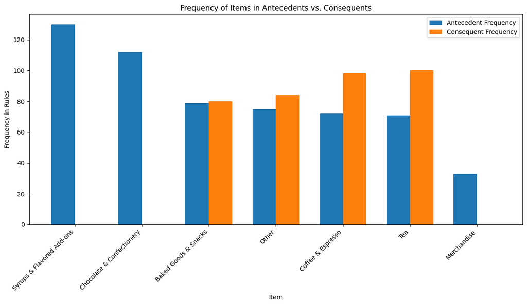

```python
# Count frequency of items in antecedents and consequents
antecedent_counts = {}
consequent_counts = {}

for index, rule in rules_train_best.iterrows():
    for item in rule['antecedents']:
        antecedent_counts[item] = antecedent_counts.get(item, 0) + 1
    for item in rule['consequents']:
        consequent_counts[item] = consequent_counts.get(item, 0) + 1

# Convert counts to DataFrames for easier plotting
antecedent_df = pd.DataFrame(list(antecedent_counts.items()), columns=['Item', 'Antecedent_Frequency'])
consequent_df = pd.DataFrame(list(consequent_counts.items()), columns=['Item', 'Consequent_Frequency'])

# Merge the two dataframes
frequency_comparison_df = pd.merge(antecedent_df, consequent_df, on='Item', how='outer').fillna(0)

# Sort for better visualization
frequency_comparison_df = frequency_comparison_df.sort_values(by=['Antecedent_Frequency', 'Consequent_Frequency'], ascending=False)

# Plot the comparison
plt.figure(figsize=(12, 7))
bar_width = 0.35
index = np.arange(len(frequency_comparison_df['Item']))

plt.bar(index, frequency_comparison_df['Antecedent_Frequency'], bar_width, label='Antecedent Frequency')
plt.bar(index + bar_width, frequency_comparison_df['Consequent_Frequency'], bar_width, label='Consequent Frequency')

plt.xlabel('Item')
plt.ylabel('Frequency in Rules')
plt.title('Frequency of Items in Antecedents vs. Consequents')
plt.xticks(index + bar_width / 2, frequency_comparison_df['Item'], rotation=45, ha='right')
plt.legend()
plt.tight_layout()
plt.show()
```

Key Insights

- Syrups & Flavored Add-ons are the most common starting point in rules, meaning customers often add these first before buying something else.
- Tea leads the list as a follow-up purchase, suggesting it's frequently paired as a secondary item.
- Merchandise consistently ranks lowest in both roles, indicating it is not tightly coupled with other categories.

## Let's Check The Numbers

Initial capital Investment **Data Infrastructure**

- Upgrading POS or integrating a data-capture layer: USD2,000 - USD5,000
- Cloud storage or on-premise database setup: USD500 to USD1,500
- Software Development
- Backend integration of association-rule engine: USD3,000 to USD7,000
- Front-end UI changes (suggestion pop-ups, digital menus): USD1,500 to USD3,000
- Hardware Upgrades
- Digital displays or tablets for in-store recommendations: USD300 to USD800 per unit
- Networking equipment (if needed): USD200 to USD500
- Staff Training: 4-6 hours of training at USD15-USD20/hour: USD60 to USD120 per employee

**Ongoing variable Operational Costs**

- Model Maintenance & Updates
- Monthly tune-ups and retraining: $200 - $500/month
- Software patching and support: $100 - $300/month
- Inventory Carrying Costs
- Extra stock of high-velocity add-ons (syrups, pastries): 15-20% higher holding costs
- Cold-chain or shelf-space adjustments: incremental square-foot cost
- Marketing & Promotions
- Bundling discounts (e.g., “add syrup for USD0.50”): margin reduction of 5 - 10% on promoted items
- A/B testing campaigns: USD100 - USD300 per test

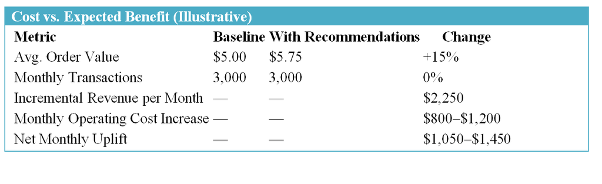

We are recommending running the Recommendation for 4 weeks as a pilot test program.

If the management consented to doing that, here are the full numbers for 4 weeks test run;

One-Time Setup Costs:

- Data infrastructure (POS upgrade): USD2,000
- Cloud storage provisioning: USD500
- Backend integration of association-rule engine: USD5,000
- Front-end UI changes (recommendation pop-ups): USD2,000
- Hardware (tablet for POS recommendations): USD500
- Networking equipment (router/switch): USD200
- Staff training (2 employees x 5 hrs x USD20/hr): USD200

Pilot Operational Costs (4 Weeks)

- Model maintenance & retraining: USD200
- Software support & patching: USD150
- Inventory carrying cost premium (extra syrups, pastries): USD200
- A/B testing campaigns & tooling: USD300
- Promotion margin impact (10% discount on add-ons): USD250

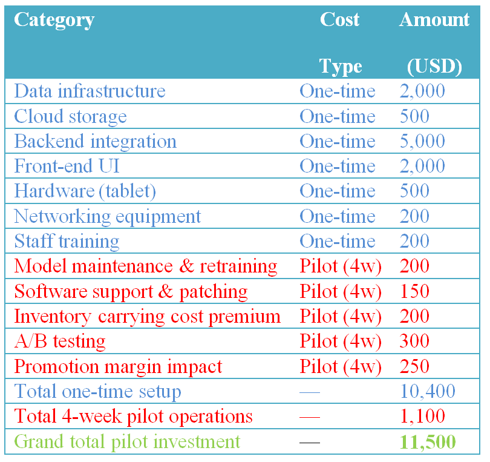

## Profitability Analysis for 4-Week Pilot

4-Week Sales & Revenue Baseline

- Baseline average order value: USD5.00
- Average daily transactions: 100
- Pilot duration: 28 days
- Baseline revenue: USD5.00 X 2,800 = USD14,000

Projected Revenue with Recommendations

- New average order value: USD5.75
- Projected revenue: USD5.75 x 2,800 = USD16,100
- Incremental revenue: USD16,100 - USD14,000 = USD2,100

ROI & Payback

- ROI for pilot period: USD1,000 / USD11,500 ≈ 8.7%
- Payback period for full investment: USD11,500 / USD1,000 ≈ 11.5 months

Conclusion The 4-week pilot generates a USD1,000 net profit after deducting its USD1,100 in variable costs. Against the USD11,500 total investment, this equates to an 8.7% return and suggests a full payback in about 11.5 months. Excluding one-time setup fees, the recurring model covers its ongoing costs within the first month. Given the strategic upside—higher basket size, richer customer data and the ability to scale across lanes and stores—this pilot shows a path to profitable expansion once rolled out at scale

```python
%%shell
jupyter nbconvert --to html '/content/drive/My Drive/SMU MSDS/Decision Analysis/Project/Coffee Shop Sales_2.csv'
```